# Impact of storms on health and economics across the United States

Torben Griebe

August 2014

## Synopsis

This report tries to find the impact of different storm events on population health and economics across the United States. The storm data provided by the U.S. National Oceanic and Atmospheric Administration is used to identify:

- the most harmful events with respect to population health and
- the events with the greatest economic consequences.

The results show, that tornados are by far the most harmful events with respect to population health. In contrast the greatest economic consequences are caused by floods. It was also possible to show, that both tornados and floods have great impact on both population health and economics.

## Data loading and processing

The necessary [storm data](https://d396qusza40orc.cloudfront.net/repdata%2Fdata%2FStormData.csv.bz2) is obtained from the U.S. National Oceanic and Atmospheric Administration’s storm database and stored into a subfolder named `data`.

```r
file.name <- "data/repdata_data_StormData.csv.bz2"
url <- "https://d396qusza40orc.cloudfront.net/repdata%2Fdata%2FStormData.csv.bz2"
if (!file.exists(file.name)) {
  dir.create("data")
  # OS dependencies
  switch(Sys.info()[['sysname']],
         Windows = {download.file(url, file.name)},
         Darwin = {download.file(url, file.name, method="curl")})
}
```

### Reading in the data

In a first step, the raw data obtained in the previous step is read in. The data in the uncompressed file is a comma separated file. The first row is a header line. Missing values are simply left out.

```r
storm.data <- read.csv(file.name, na.strings="")
```

After reading in the data, the number of observations and variables are obtained to get a first insight in the data available.

```r
dim(storm.data)
```

```
## [1] 902297     37
```

As stated, there are 902297 observations of 37 different variables.

### Relevant variables

To get an idea of the relevant variables, the structure of the data is examined in combination with the [National Weather Service Storm Data Documentation](https://d396qusza40orc.cloudfront.net/repdata%2Fpeer2_doc%2Fpd01016005curr.pdf) (from here on out called “SDD”) which was provided as part of the peer assessment 2 description of the Coursera “Reproducible Research” course.

```r
str(storm.data)
```

```
## 'data.frame':    902297 obs. of  37 variables:
##  $ STATE__   : num  1 1 1 1 1 1 1 1 1 1 ...
##  $ BGN_DATE  : Factor w/ 16335 levels "1/1/1966 0:00:00",..: 6523 6523 4242 11116 2224 2224 2260 383 3980 3980 ...
##  $ BGN_TIME  : Factor w/ 3608 levels "00:00:00 AM",..: 272 287 2705 1683 2584 3186 242 1683 3186 3186 ...
##  $ TIME_ZONE : Factor w/ 22 levels "ADT","AKS","AST",..: 7 7 7 7 7 7 7 7 7 7 ...
##  $ COUNTY    : num  97 3 57 89 43 77 9 123 125 57 ...
##  $ COUNTYNAME: Factor w/ 29600 levels "5NM E OF MACKINAC BRIDGE TO PRESQUE ISLE LT MI",..: 13512 1872 4597 10591 4371 10093 1972 23872 24417 4597 ...
##  $ STATE     : Factor w/ 72 levels "AK","AL","AM",..: 2 2 2 2 2 2 2 2 2 2 ...
##  $ EVTYPE    : Factor w/ 985 levels "   HIGH SURF ADVISORY",..: 834 834 834 834 834 834 834 834 834 834 ...
##  $ BGN_RANGE : num  0 0 0 0 0 0 0 0 0 0 ...
##  $ BGN_AZI   : Factor w/ 34 levels "  N"," NW","E",..: NA NA NA NA NA NA NA NA NA NA ...
##  $ BGN_LOCATI: Factor w/ 54428 levels " Christiansburg",..: NA NA NA NA NA NA NA NA NA NA ...
##  $ END_DATE  : Factor w/ 6662 levels "1/1/1993 0:00:00",..: NA NA NA NA NA NA NA NA NA NA ...
##  $ END_TIME  : Factor w/ 3646 levels " 0900CST"," 200CST",..: NA NA NA NA NA NA NA NA NA NA ...
##  $ COUNTY_END: num  0 0 0 0 0 0 0 0 0 0 ...
```

[output cut: 23 more lines]

As stated in chapter 2.6 of the SDD and in reconciliation with the variable names, the variables `INJURIES` and `FATALITIES` together specifiy the impact on the population health.

The variables `PROPDMG`, `PROPDMGEXP`, `CROPDMG` and `CROPDMGEXP` describe the economic consequences (see chapter 2.7 of the SDD)

The last variable needed is named `EVTYPE` as described in the description of the peer assessment.

### Cleaning up health and economics data

To investigate the two questions, two separate sub-datasets will be created and separately examined. But before that, the common variable `EVTYPE` is analyzed.

#### Cleaning up common data

After a first look at the values of `EVTYPE` (the values won’t be displayed here so the report doesn’t get overfilled) it turns out, that the values are string formatted. Furthermore some of them contains leading or double whitespaces or consist of only capital letters. Some of them contain abbreviated words like “TSTM” for “thunderstorm” or are written in plural vs. singular. To simplify the future usage of this variable, unnecessary whitespaces are stripped and all letters are converted to lowercase. Additionally, nondescriptive characters like slashes or dashes are deleted and the abbreviation “tstm” is written out. These actions remove some duplicated event types.

```r
num.of.levels = length(levels(storm.data$EVTYPE))
storm.data$EVTYPE = tolower(gsub("[&[:punct:]]", " ",
                                 storm.data$EVTYPE, perl=TRUE))
storm.data$EVTYPE = gsub("^[[:space:]]*(.*?)[[:space:]]*$", "\\1",
                         storm.data$EVTYPE, perl=TRUE)
storm.data$EVTYPE = gsub("[[:space:]]{2,}", " ",
                         storm.data$EVTYPE, perl=TRUE)
storm.data$EVTYPE = factor(gsub("tstm", "thunderstorm", storm.data$EVTYPE))
cat(sprintf("Deleted %d duplicates",
            num.of.levels - length(levels(storm.data$EVTYPE))))
```

```
## Deleted 157 duplicates
```

There are many more posibilities to consolidate the event types, e.g.:

- Correction of typing errors
- Writing out more abbreviations
- Removing plural suffixes
- Contextual merging

But due to shortage of time, this isn’t part of this report. But in my opinion, it is definetly an issue for a more in-depth report.

#### Cleaning up health data

```r
health.data <- storm.data[, c("EVTYPE", "FATALITIES", "INJURIES")]
names(health.data) <- c("event.type", "fatalities", "injuries")
```

To get an overview of the data, a short summary is displayed.

```r
summary(health.data)
```

```
##               event.type       fatalities     injuries
##  thunderstorm wind :302511   Min.   :  0   Min.   :   0.0
##  hail              :288661   1st Qu.:  0   1st Qu.:   0.0
##  tornado           : 60652   Median :  0   Median :   0.0
##  flash flood       : 54279   Mean   :  0   Mean   :   0.2
##  flood             : 25327   3rd Qu.:  0   3rd Qu.:   0.0
##  thunderstorm winds: 20859   Max.   :583   Max.   :1700.0
##  (Other)           :150008
```

The variables `fatalities` and `injuries` contain only valid values. There are no NA-values or negative numbers.

In this report, fatalities and injuries are combined to one value called `health.damage`.

```r
health.data$health.damage <- rowSums(health.data[, c("fatalities", "injuries")])
```

For another more in-depth research, they should be kept separate or they should be weighted differently before they are summed up. At least in my opinion a fatality is more severe than only an injury.

#### Cleaning up economics data

```r
economics.data <- storm.data[, c("EVTYPE", "PROPDMG", "PROPDMGEXP",
                                 "CROPDMG", "CROPDMGEXP")]
names(economics.data) <- c("event.type",
                           "property.damage", "property.magnitude.char",
                           "crop.damage", "crop.magnitude.char")
```

As before, a short summary is displayed for an overview of the data.

```r
summary(economics.data)
```

```
##               event.type     property.damage property.magnitude.char
##  thunderstorm wind :302511   Min.   :   0    K      :424665
##  hail              :288661   1st Qu.:   0    M      : 11330
##  tornado           : 60652   Median :   0    0      :   216
##  flash flood       : 54279   Mean   :  12    B      :    40
##  flood             : 25327   3rd Qu.:   0    5      :    28
##  thunderstorm winds: 20859   Max.   :5000    (Other):    84
##  (Other)           :150008                   NA's   :465934
##   crop.damage    crop.magnitude.char
##  Min.   :  0.0   K      :281832
##  1st Qu.:  0.0   M      :  1994
##  Median :  0.0   k      :    21
##  Mean   :  1.5   0      :    19
##  3rd Qu.:  0.0   B      :     9
##  Max.   :990.0   (Other):     9
##                  NA's   :618413
```

First of all the variables `property.damage` and `crop.damage` contain no NA-values or negative numbers. But the corresponding two variables `property.magnitude.char` and `crop.magnitude.char` representing the magnitude numbers seem to contain some undefined and invalid values. As the SDD specifies, these values should only contain the characters “K”, “M” or “B” (see SDD, chapter 2.7).

Therefore a closer look at these to variables is required. On a first try it is checked, if there is any damage specified with no (i.e. NA) magnitude number.

```r
sum(economics.data$property.damage)
```

```
## [1] 10884500
```

```r
sum(economics.data$property.damage[is.na(economics.data$property.magnitude.char)])
```

```
## [1] 527.4
```

```r
sum(economics.data$crop.damage)
```

```
## [1] 1377827
```

```r
sum(economics.data$crop.damage[is.na(economics.data$crop.magnitude.char)])
```

```
## [1] 11
```

Overall these observations can be ignored in further calculations because of there extremly small portion.

Now the invalid magnitude numbers are inspected.

```r
levels(economics.data$property.magnitude.char)
```

```
##  [1] "-" "?" "+" "0" "1" "2" "3" "4" "5" "6" "7" "8" "B" "h" "H" "K" "m"
## [18] "M"
```

```r
levels(economics.data$crop.magnitude.char)
```

```
## [1] "?" "0" "2" "B" "k" "K" "m" "M"
```

Some of the allowed values are present both in upper and lower case letters. This issue is solved by converting all values to lower case.

```r
economics.data$property.magnitude.char <-
  factor(tolower(economics.data$property.magnitude.char))
economics.data$crop.magnitude.char <-
  factor(tolower(economics.data$crop.magnitude.char))
```

To get an idea of what to do with the other values, the relative occurrence of them in respect to the occurences of the valid values is analyzed.

```r
mean(!economics.data$property.magnitude.char[
  !is.na(economics.data$property.magnitude.char)] %in% c("b", "k", "m"))
```

```
## [1] 0.0007356
```

```r
mean(!economics.data$crop.magnitude.char[
  !is.na(economics.data$crop.magnitude.char)] %in% c("b", "k", "m"))
```

```
## [1] 9.511e-05
```

The ratio is small enough to ignore these invalid values, too.

Now, the damage represented by the variable `[...].damage` and the alphabetical magnitude variable `[...].magnitude.char` can be converted into actual damage values. The calculated damage values are stored in the corresponding variable `[...].damage.value`.

```r
economics.data$property.damage.value <-
  apply(economics.data[, c("property.damage", "property.magnitude.char")],
        1, function(x) {
          switch(x[2],
                 k={as.numeric(x[1]) * 10^3},
                 m={as.numeric(x[1]) * 10^6},
                 b={as.numeric(x[1]) * 10^9},
                 {as.numeric(x[1])})
          })
economics.data$crop.damage.value <-
  apply(economics.data[, c("crop.damage", "crop.magnitude.char")],
        1, function(x) {
          switch(x[2],
                 k={as.numeric(x[1]) * 10^3},
                 m={as.numeric(x[1]) * 10^6},
                 b={as.numeric(x[1]) * 10^9},
                 {as.numeric(x[1])})
          })
```

In a last step, the overall damage values are stored into a new variable called `economics.damage`.

```r
economics.data$economics.damage <-
  rowSums(economics.data[, c("property.damage.value", "crop.damage.value")])
```

### Processing health and economics data

After loading and cleaning up the data, the data can be processed to answer the question mentioned at the beginning of this report. Therefore the injuries and fatalities, as well as the economic damage are aggregated by the event type.

```r
health.impact <- aggregate(health.damage ~ event.type,
                           health.data, sum)
economics.impact <- aggregate(economics.damage ~ event.type,
                              economics.data, sum)
```

The aggregated data is now ordered decreasing by the amount of damage to get an ordered list with the most harmful events on the top.

```r
health.impact <- health.impact[order(health.impact$health.damage,
                                     decreasing=TRUE), ]
row.names(health.impact) <- seq_len(nrow(health.impact))

economics.impact <- economics.impact[order(economics.impact$economics.damage,
                                           decreasing=TRUE), ]
row.names(economics.impact) <- seq_len(nrow(economics.impact))
```

## Results

**Question 1: Across the United States, which types of events are most harmful with respect to population health?**

The following table show the 20 most harmful storm events. The first column describes the event, the second column contains the amount of “damage”. In this case, damage means injuries and fatalities.

```r
library(xtable)
print(xtable(head(health.impact, n=20)), type="html")
```

|  | event.type | health.damage |
| --- | --- | --- |
| 1 | tornado | 96979.00 |
| 2 | thunderstorm wind | 9082.00 |
| 3 | excessive heat | 8428.00 |
| 4 | flood | 7259.00 |
| 5 | lightning | 6047.00 |
| 6 | heat | 3037.00 |
| 7 | flash flood | 2755.00 |
| 8 | ice storm | 2064.00 |
| 9 | winter storm | 1527.00 |
| 10 | high wind | 1385.00 |
| 11 | hail | 1376.00 |
| 12 | hurricane typhoon | 1339.00 |
| 13 | heavy snow | 1148.00 |
| 14 | wildfire | 986.00 |
| 15 | thunderstorm winds | 982.00 |
| 16 | blizzard | 906.00 |
| 17 | fog | 796.00 |
| 18 | rip current | 600.00 |
| 19 | wild forest fire | 557.00 |
| 20 | heat wave | 551.00 |

**Question 2: Across the United States, which types of events have the greatest economic consequences?**

Below are the top 20 storm events displayed that have the greatest economic consequences across the United States. As before, the first column describes the event. The second column states the amount of economics damage in Dollar.

```r
print(xtable(head(economics.impact, n=20)), type="html")
```

|  | event.type | economics.damage |
| --- | --- | --- |
| 1 | flood | 150319678257.00 |
| 2 | hurricane typhoon | 71913712800.00 |
| 3 | tornado | 57352114048.70 |
| 4 | storm surge | 43323541000.00 |
| 5 | hail | 18758221520.70 |
| 6 | flash flood | 17562679167.10 |
| 7 | drought | 15018672000.00 |
| 8 | hurricane | 14610229010.00 |
| 9 | river flood | 10148404500.00 |
| 10 | ice storm | 8967041360.00 |
| 11 | thunderstorm wind | 8945033179.00 |
| 12 | tropical storm | 8382236550.00 |
| 13 | winter storm | 6715441251.00 |
| 14 | high wind | 5908617595.00 |
| 15 | wildfire | 5060586800.00 |
| 16 | storm surge tide | 4642038000.00 |
| 17 | hurricane opal | 3191846000.00 |
| 18 | wild forest fire | 3108626330.00 |
| 19 | heavy rain severe weather | 2500000000.00 |
| 20 | thunderstorm winds | 1926702811.20 |

*Note: As the results show, some of the event types are duplicates, differing only in the plural suffix (e.g. “thunderstorm wind” and “thunderstorm winds”). Others might be handled as contextual identical (e.g. “excessive heat” and “heat wave”). Therefore, the optimizations mentioned in the chapter “Cleaning up common data” would improve the performance of the results.*

The following graph shows the connection between the top event types regarding population health harm and economics consequences. This way, you can get an idea of the event types that might cause great damage to both “damage types”. To keep the graph clear, the legend is not displayed. But both the “Health” and the “Economics” column are ordered like in the corresponding tables above.

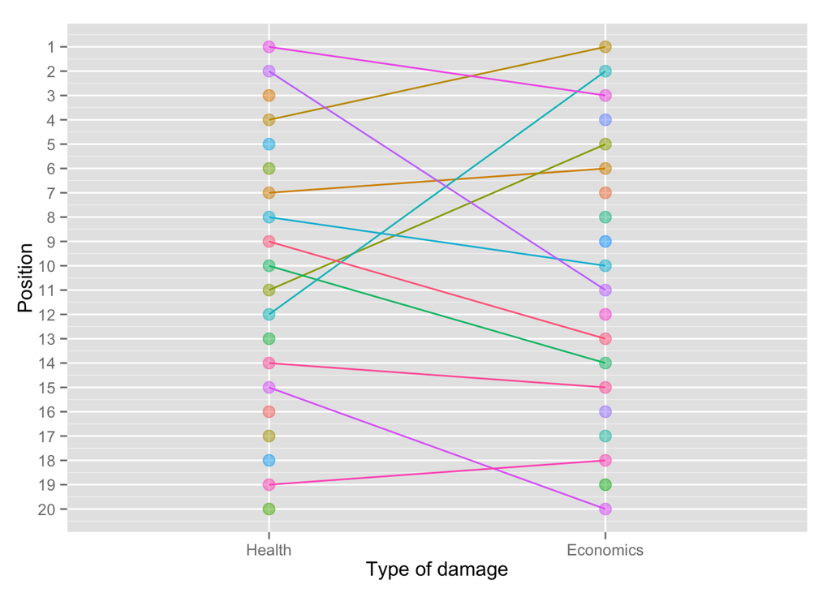

```r
library(ggplot2)
library(reshape2)
plot.data <- data.frame(pos=seq(from=20, to=1),  # reverse scale y
                        health.event.type=health.impact$event.type[1:20],
                        economics.event.type=economics.impact$event.type[1:20])
plot.data <- melt(plot.data, id.vars=1)
print(g <- ggplot(data=plot.data, aes(variable, pos, group=value, colour=value))
      + geom_point(size=5, pch=20, alpha=0.5)
      + geom_line()
      + scale_x_discrete(name="Type of damage", labels=c("Health", "Economics"))
      + scale_y_continuous(name="Position", breaks=seq(from=1, to=20),
                           labels=seq(from=20, to=1))  # reverse scale y
      + theme(legend.position="none"))
```

As the plot shows, tornado and flood events are in the top 4 of both damage types. This might help to decide, on what event types actions should be taken for reducing the damage caused by these events.